# MSDS458_Assignment_01_Experiment 1

Parviz Ali MSDS 458 Prof. Srinivasan (Fall 2021)

## 1. Importing Packages

- First we import all the packages that will be used in the assignment.
- Since Keras is integrated in TensorFlow 2.x, we import `keras` from `tensorflow` and use `tenserflow.keras.xxx` to import all other Keras packages. The seed argument produces a deterministic sequence of tensors across multiple calls.

```python
import datetime
from packaging import version
from collections import Counter
import numpy as np
import pandas as pd

import matplotlib as mpl  # EA
import matplotlib.pyplot as plt
from mpl_toolkits.mplot3d import Axes3D
import seaborn as sns

from sklearn.metrics import confusion_matrix, classification_report
from sklearn.preprocessing import StandardScaler
from sklearn.decomposition import PCA
from sklearn.manifold import TSNE
from sklearn.ensemble import RandomForestClassifier
from sklearn.metrics import mean_squared_error as MSE
from sklearn.metrics import accuracy_score

import tensorflow as tf
from tensorflow.keras.utils import to_categorical
from tensorflow import keras
from tensorflow.keras import models
from tensorflow.keras.models import Sequential
from tensorflow.keras.layers import Dense, Flatten
from tensorflow.keras.datasets import mnist
#from plot_keras_history import plot_history
```

```python
%matplotlib inline
np.set_printoptions(precision=3, suppress=True)
```

### Functions For Research Assignment

```python
def print_validation_report(test_labels, predictions):
    print("Classification Report")
    print(classification_report(test_labels, predictions))
    print('Accuracy Score: {}'.format(accuracy_score(test_labels, predictions)))
    print('Root Mean Square Error: {}'.format(np.sqrt(MSE(test_labels, predictions))))
```

```python
def plot_confusion_matrix(y_true, y_pred):
    mtx = confusion_matrix(y_true, y_pred)
    fig, ax = plt.subplots(figsize=(8,8))
    sns.heatmap(mtx, annot=True, fmt='d', linewidths=.75,  cbar=False, ax=ax,cmap='Blues',linecolor='white')
    #  square=True,
    plt.ylabel('true label')
    plt.xlabel('predicted label')
```

```python
# To get consistint results each time we rerun the code.
keras.backend.clear_session()
np.random.seed(42)
tf.random.set_seed(42)
```

## 2. Loading MNIST Dataset

- The MNIST dataset of handwritten digits has a training set of 60,000 images, and a test set of 10,000 images. It comes prepackaged as part of `tf.Keras`. Use the `tf.keras.datasets.mnist.load_data` to the get these datasets (and the corresponding labels) as Numpy arrays.

```python
(x_train, y_train), (x_test, y_test)= tf.keras.datasets.mnist.load_data()
```

```
Downloading data from https://storage.googleapis.com/tensorflow/tf-keras-datasets/mnist.npz
```

- Tuples of Numpy arrays: `(x_train, y_train)`, `(x_test, y_test)`
- `x_train`, `x_test`: uint8 arrays of grayscale image data with shapes (num_samples, 28, 28).
- `y_train`, `y_test`: uint8 arrays of digit labels (integers in range 0-9)

## 3. EDA Training and Test Sets

- Inspect the training and test sets as well as their labels as follows.

```python
print('x_train:\t{}'.format(x_train.shape))
print('y_train:\t{}'.format(y_train.shape))
print('x_test:\t\t{}'.format(x_test.shape))
print('y_test:\t\t{}'.format(y_test.shape))
```

```
x_train:	(60000, 28, 28)
y_train:	(60000,)
x_test:		(10000, 28, 28)
y_test:		(10000,)
```

### Review labels for training set

```python
print("First ten labels training dataset:\n {}\n".format(y_train[0:10]))
```

```
First ten labels training dataset:
 [5 0 4 1 9 2 1 3 1 4]
```

### Find frequency of each label in training and test sets

```python
Counter(y_train).most_common()
```

```
[(1, 6742),
 (7, 6265),
 (3, 6131),
 (2, 5958),
 (9, 5949),
 (0, 5923),
 (6, 5918),
 (8, 5851),
 (4, 5842),
 (5, 5421)]
```

```python
Counter(y_test).most_common()
```

```
[(1, 1135),
 (2, 1032),
 (7, 1028),
 (3, 1010),
 (9, 1009),
 (4, 982),
 (0, 980),
 (8, 974),
 (6, 958),
 (5, 892)]
```

### Plot sample images with their labels

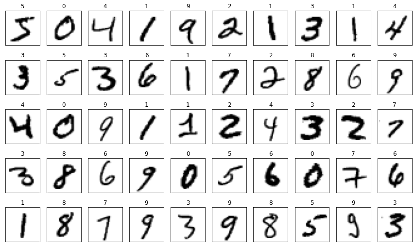

```python
fig = plt.figure(figsize = (15, 9))

for i in range(50):
    plt.subplot(5, 10, 1+i)
    plt.title(y_train[i])
    plt.xticks([])
    plt.yticks([])
    plt.imshow(x_train[i].reshape(28,28), cmap='binary')
```

## 4. Preprocessing Data

- Before we build our model, we need to prepare the data into the shape the network expected
- More specifically, we will convert the labels (integers 0 to 9) to 1D numpy arrays of shape (10,) with elements 0s and 1s.
- We also reshape the images from 2D arrays of shape (28,28) to 1D *float32* arrays of shape (784,) and then rescale their elements to values between 0 and 1.

### Apply one-hot encoding on the labels

We will change the way the labels are represented from numbers (0 to 9) to vectors (1D arrays) of shape (10, ) with all the elements set to 0 except the one which the label belongs to - which will be set to 1. For example:

| original label | one-hot encoded label |
| --- | --- |
| 5 | [0 0 0 0 0 1 0 0 0 0] |
| 7 | [0 0 0 0 0 0 0 1 0 0] |
| 1 | [0 1 0 0 0 0 0 0 0 0] |

```python
y_train_encoded = to_categorical(y_train)
y_test_encoded = to_categorical(y_test)

print("First ten entries of y_train:\n {}\n".format(y_train[0:10]))
print("First ten rows of one-hot y_train:\n {}".format(y_train_encoded[0:10,]))
```

```
First ten entries of y_train:
 [5 0 4 1 9 2 1 3 1 4]

First ten rows of one-hot y_train:
 [[0. 0. 0. 0. 0. 1. 0. 0. 0. 0.]
 [1. 0. 0. 0. 0. 0. 0. 0. 0. 0.]
 [0. 0. 0. 0. 1. 0. 0. 0. 0. 0.]
 [0. 1. 0. 0. 0. 0. 0. 0. 0. 0.]
 [0. 0. 0. 0. 0. 0. 0. 0. 0. 1.]
 [0. 0. 1. 0. 0. 0. 0. 0. 0. 0.]
 [0. 1. 0. 0. 0. 0. 0. 0. 0. 0.]
 [0. 0. 0. 1. 0. 0. 0. 0. 0. 0.]
 [0. 1. 0. 0. 0. 0. 0. 0. 0. 0.]
 [0. 0. 0. 0. 1. 0. 0. 0. 0. 0.]]
```

```python
print('y_train_encoded shape: ', y_train_encoded.shape)
print('y_test_encoded shape: ', y_test_encoded.shape)
```

```
y_train_encoded shape:  (60000, 10)
y_test_encoded shape:  (10000, 10)
```

### Reshape the images to 1D arrays

Reshape the images from shape (28, 28) 2D arrays to shape (784, ) vectors (1D arrays).

```python
# Before reshape:
print('x_train:\t{}'.format(x_train.shape))
print('x_test:\t\t{}'.format(x_test.shape))
```

```
x_train:	(60000, 28, 28)
x_test:		(10000, 28, 28)
```

```python
np.set_printoptions(linewidth=np.inf)
print("{}".format(x_train[2022]))
```

```
[[  0   0   0   0   0   0   0   0   0   0   0   0   0   0   0   0   0   0   0   0   0   0   0   0   0   0   0   0]
 [  0   0   0   0   0   0   0   0   0   0   0   0   0   0   0   0   0   0   0   0   0   0   0   0   0   0   0   0]
 [  0   0   0   0   0   0   0   0   0   0   0   0   0   0   0   0   0   0   0   0   0   0   0   0   0   0   0   0]
 [  0   0   0   0   0   0   0   0   0   0   0   0   0   0   0   0   0   0   0   0   0   0   0   0   0   0   0   0]
 [  0   0   0   0   0   0   0   0   0   0   0   0   0   0   0   0   0   0   0   0   0   0   0   0   0   0   0   0]
 [  0   0   0   0   0   0   0   0   0   0   0   0  48  18   0   0   0   0   0   0   0   0   0   0   0   0   0   0]
 [  0   0   0   0   0   0   0   0   3  71 149 223 242 230 223 153  29   1   0   0   0   0   0   0   0   0   0   0]
 [  0   0   0   0   0   0   0  14 185 254 254 254 254 240 251 254 254 100   0   0   0   0   0   0   0   0   0   0]
 [  0   0   0   0   0   0  64 209 254 206 138  65  65  43  60 151 254 249  65   0   0   0   0   0   0   0   0   0]
 [  0   0   0   0   0   0 240 254 254 108   0   0   0   0   0   6 155 254 137   0   0   0   0   0   0   0   0   0]
 [  0   0   0   0   0   0  73 205 205 170   0   0   0   0   0   0  36 245 206  10   0   0   0   0   0   0   0   0]
 [  0   0   0   0   0   0   0   0   0   0   0   0   0   0   0   0   0 239 254  48   0   0   0   0   0   0   0   0]
 [  0   0   0   0   0   0   0   0   0   0   0   0   0   0   0   0   0 239 254  48   0   0   0   0   0   0   0   0]
 [  0   0   0   0   0   0   0   0   0   0   0   0   0   0   0   0  60 249 242  38   0   0   0   0   0   0   0   0]
 [  0   0   0   0   0   0   0   0   0   0   0   0   0   0   0  20 198 254 109   0   0   0   0   0   0   0   0   0]
 [  0   0   0   0   0   0   0   0   0   0   0   0   0   0   0  64 254 225   6   0   0   0   0   0   0   0   0   0]
 [  0   0   0   0   0   0   0   0   2  79 133  60  60  14  84 224 254  53   0   0   0   0   0   0   0   0   0   0]
 [  0   0   0   0   0   0   0   0   6 254 254 254 254 218 230 254 254 108  99  99  99  99 188 207 207 207   0   0]
 [  0   0   0   0   0   0   0   0   6 254 176  11  79 254 254 237 227 227 227 227 253 254 141 119  89  10   0   0]
 [  0   0   0   0   0   0   0   0   6 254 229 131 254 254 169  29   0   0   0   0  78  81  14   0   0   0   0   0]
 [  0   0   0   0   0   0   0   0   1 169 254 254 254 175  31   0   0   0   0   0   0   0   0   0   0   0   0   0]
 [  0   0   0   0   0   0   0   0   0  87 246 253 201  27   0   0   0   0   0   0   0   0   0   0   0   0   0   0]
 [  0   0   0   0   0   0   0   0   0   0  57  72   0   0   0   0   0   0   0   0   0   0   0   0   0   0   0   0]
 [  0   0   0   0   0   0   0   0   0   0   0   0   0   0   0   0   0   0   0   0   0   0   0   0   0   0   0   0]
 [  0   0   0   0   0   0   0   0   0   0   0   0   0   0   0   0   0   0   0   0   0   0   0   0   0   0   0   0]
 [  0   0   0   0   0   0   0   0   0   0   0   0   0   0   0   0   0   0   0   0   0   0   0   0   0   0   0   0]
 [  0   0   0   0   0   0   0   0   0   0   0   0   0   0   0   0   0   0   0   0   0   0   0   0   0   0   0   0]
 [  0   0   0   0   0   0   0   0   0   0   0   0   0   0   0   0   0   0   0   0   0   0   0   0   0   0   0   0]]
```

```python
# Reshape the images:
x_train_reshaped = np.reshape(x_train, (60000, 784))
x_test_reshaped = np.reshape(x_test, (10000, 784))

# After reshape:
print('x_train_reshaped shape: ', x_train_reshaped.shape)
print('x_test_reshaped shape: ', x_test_reshaped.shape)
```

```
x_train_reshaped shape:  (60000, 784)
x_test_reshaped shape:  (10000, 784)
```

1. Each element in an image is a pixel value
2. Pixel values range from 0 to 255
3. 0 = White
4. 255 = Black

### Review unique values with set from 1st image

```python
print(set(x_train_reshaped[0]))
```

```
{0, 1, 2, 3, 9, 11, 14, 16, 18, 23, 24, 25, 26, 27, 30, 35, 36, 39, 43, 45, 46, 49, 55, 56, 64, 66, 70, 78, 80, 81, 82, 90, 93, 94, 107, 108, 114, 119, 126, 127, 130, 132, 133, 135, 136, 139, 148, 150, 154, 156, 160, 166, 170, 171, 172, 175, 182, 183, 186, 187, 190, 195, 198, 201, 205, 207, 212, 213…
```

### Rescale the elements of the reshaped images

Rescale the elements between [0 and 1]

```python
x_train_norm = x_train_reshaped.astype('float32') / 255
x_test_norm = x_test_reshaped.astype('float32') / 255
```

```python
# Take a look at the first reshaped and normalized training image:
print(set(x_train_norm[0]))
```

```
{0.0, 0.011764706, 0.53333336, 0.07058824, 0.49411765, 0.6862745, 0.101960786, 0.6509804, 1.0, 0.96862745, 0.49803922, 0.11764706, 0.14117648, 0.36862746, 0.6039216, 0.6666667, 0.043137256, 0.05490196, 0.03529412, 0.85882354, 0.7764706, 0.7137255, 0.94509804, 0.3137255, 0.6117647, 0.41960785, 0.2588…
```

## 5. Creating the DNN Model

- In this step, we first choose the network architecture for the model. Then we build.compile, train and evaulate the model.

### Specify the network architecture

Below is the neural network architecture we will use today for classifying MNIST digits.

[figure not shown]

### Build the DNN model

We use a `Sequential` class defined in `Keras` to create our model. All the layers are going to be Dense layers. This means, like the figure shown above, all the nodes of a layer would be connected to all the nodes of the preceding layer i.e. densely connected.

```python
model = Sequential([
    Dense(input_shape=[784], units=1, activation = tf.nn.relu,kernel_regularizer=tf.keras.regularizers.L2(0.001)),
    Dense(name = "output_layer", units = 10, activation = tf.nn.softmax)
])
```

```python
model.summary()
```

```
Model: "sequential_1"
_________________________________________________________________
Layer (type)                 Output Shape              Param #
=================================================================
dense_1 (Dense)              (None, 1)                 785
_________________________________________________________________
output_layer (Dense)         (None, 10)                20
=================================================================
Total params: 805
Trainable params: 805
Non-trainable params: 0
_________________________________________________________________
```

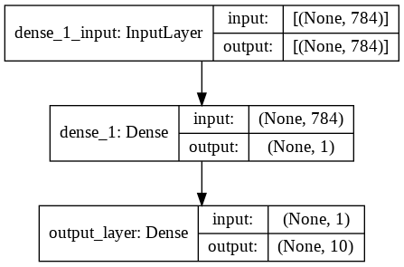

```python
keras.utils.plot_model(model, "mnist_model.png", show_shapes=True)
```

### Compile the DNN model

In addition to setting up our model architecture, we also need to define which algorithm should the model use in order to optimize the weights and biases as per the given data. We will use RMSprop.

We also need to define a loss function. This is the difference between the predicted outputs and the actual outputs given in the dataset. This loss needs to be minimized in order to have a higher model accuracy. That's what the optimization algorithm essentially does - it minimizes the loss during model training. For our multi-class classification problem, categorical cross entropy is commonly used.

Finally, we will use the accuracy during training as a metric to keep track of as the model trains.

```python
model.compile(optimizer='rmsprop',
               loss = 'categorical_crossentropy',
               metrics=['accuracy'])
```

### Train the DNN model with early stopping

```python
history = model.fit(
    x_train_norm
    ,y_train_encoded
    ,epochs = 200
    ,validation_split=0.20
    ,callbacks=[tf.keras.callbacks.EarlyStopping(monitor='val_accuracy', patience=2)]
    )
```

### Evaluate the DNN model

In order to ensure that this is not a simple "memorization" by the machine, we should evaluate the performance on the test set. This is easy to do, we simply use the `evaluate` method on our model.

```python
loss, accuracy = model.evaluate(x_test_norm, y_test_encoded)
print('test set accuracy: ', accuracy * 100)
```

```
test set accuracy:  35.670000314712524
```

## 6. Making Predictions

```python
preds = model.predict(x_test_norm)
print('shape of preds: ', preds.shape)
```

```
shape of preds:  (10000, 10)
```

Look at the first 25 - Plot test set images along with their predicted and actual labels to understand how the trained model actually performed

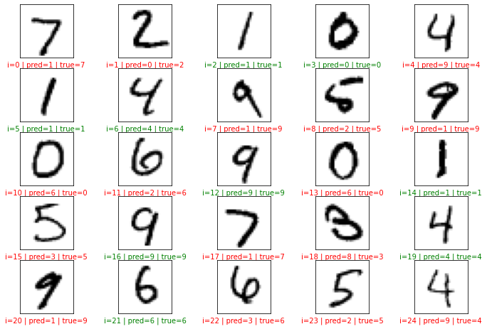

```python
plt.figure(figsize = (12, 8))

start_index = 0

for i in range(25):
    plt.subplot(5, 5, i + 1)
    plt.grid(False)
    plt.xticks([])
    plt.yticks([])
    pred = np.argmax(preds[start_index + i])
    actual = np.argmax(y_test_encoded[start_index + i])
    col = 'g'
    if pred != actual:
        col = 'r'
    plt.xlabel('i={} | pred={} | true={}'.format(start_index + i, pred, actual), color = col)
    plt.imshow(x_test[start_index + i], cmap='binary')
plt.show()
```

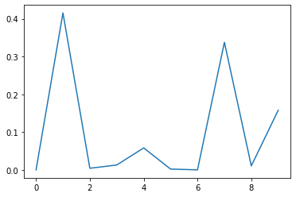

```python
"""
Enter the index value in place of the value 17 below for the prediction
that you want to plot the probability scores for
"""
index = 17

plt.plot(preds[index])
plt.show()
```

## 7. Reviewing Performance

### Plot performance metrics

We use `Matplotlib` to create 2 plots--displaying the training and validation loss (resp. accuracy) for each (training) epoch side by side.

```python
history_dict = history.history
history_dict.keys()
```

```
dict_keys(['loss', 'accuracy', 'val_loss', 'val_accuracy'])
```

```python
losses = history.history['loss']
accs = history.history['accuracy']
val_losses = history.history['val_loss']
val_accs = history.history['val_accuracy']
epochs = len(losses)
#print(losses)
#print(accs)
```

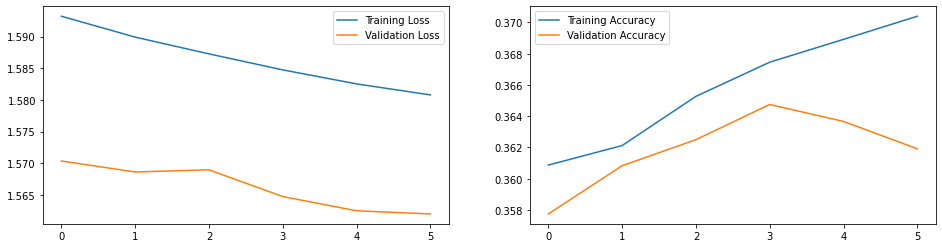

```python
plt.figure(figsize=(16, 4))
for i, metrics in enumerate(zip([losses, accs], [val_losses, val_accs], ['Loss', 'Accuracy'])):
    plt.subplot(1, 2, i + 1)
    plt.plot(range(epochs), metrics[0], label='Training {}'.format(metrics[2]))
    plt.plot(range(epochs), metrics[1], label='Validation {}'.format(metrics[2]))
    plt.legend()
plt.show()
```

```python
pred1= model.predict(x_test_norm)
pred1=np.argmax(pred1, axis=1)
```

```python
print_validation_report(y_test, pred1)
```

```
Classification Report
              precision    recall  f1-score   support

           0       0.60      0.63      0.61       980
           1       0.48      0.88      0.62      1135
           2       0.21      0.27      0.24      1032
           3       0.29      0.16      0.20      1010
           4       0.30      0.40      0.35       982
           5       0.15      0.01      0.01       892
           6       0.31      0.44      0.36       958
           7       0.23      0.09      0.13      1028
           8       0.22      0.17      0.19       974
           9       0.37      0.43      0.40      1009

    accuracy                           0.36     10000
   macro avg       0.32      0.35      0.31     10000
weighted avg       0.32      0.36      0.32     10000

Accuracy Score: 0.3567
Root Mean Square Error: 3.6585516259853432
```

### Create the confusion matrix

Let us see what the confusion matrix looks like. Using both `sklearn.metrics`. Then we visualize the confusion matrix and see what that tells us.

```python
# Get the predicted classes:
# pred_classes = model.predict_classes(x_train_norm)# give deprecation warning
pred_classes = np.argmax(model.predict(x_test_norm), axis=-1)
pred_classes;
```

**Correlation matrix that measures the linear relationships**  
https://pandas.pydata.org/pandas-docs/stable/reference/api/pandas.DataFrame.corr.html

```python
conf_mx = tf.math.confusion_matrix(y_test, pred_classes)
conf_mx;
```

```python
cm = sns.light_palette((260, 75, 60), input="husl", as_cmap=True)
df = pd.DataFrame(preds[0:20], columns = ['0', '1', '2', '3', '4', '5', '6', '7', '8', '9'])
df.style.format("{:.2%}").background_gradient(cmap=cm)
```

|  | 0 | 1 | 2 | 3 | 4 | 5 | 6 | 7 | 8 | 9 |
| --- | --- | --- | --- | --- | --- | --- | --- | --- | --- | --- |
| 0 | 0.00% | 47.23% | 0.28% | 0.87% | 4.27% | 0.14% | 0.01% | 33.61% | 0.70% | 12.89% |
| 1 | 49.69% | 0.00% | 4.70% | 1.10% | 0.04% | 7.27% | 35.65% | 0.00% | 1.55% | 0.00% |
| 2 | 0.00% | 47.18% | 0.28% | 0.87% | 4.28% | 0.14% | 0.01% | 33.61% | 0.71% | 12.92% |
| 3 | 41.74% | 0.00% | 6.89% | 1.92% | 0.10% | 9.90% | 36.83% | 0.00% | 2.61% | 0.00% |
| 4 | 0.05% | 6.32% | 5.22% | 10.58% | 23.06% | 3.19% | 0.50% | 13.77% | 9.39% | 27.93% |
| 5 | 0.00% | 47.23% | 0.28% | 0.87% | 4.27% | 0.14% | 0.01% | 33.61% | 0.70% | 12.89% |
| 6 | 0.14% | 1.95% | 8.66% | 15.14% | 25.04% | 5.64% | 1.11% | 6.22% | 13.87% | 22.23% |
| 7 | 0.00% | 33.96% | 0.77% | 2.13% | 8.39% | 0.41% | 0.04% | 32.77% | 1.77% | 19.77% |
| 8 | 2.36% | 0.00% | 20.13% | 19.05% | 9.99% | 17.08% | 9.00% | 0.06% | 19.90% | 2.43% |
| 9 | 0.00% | 47.23% | 0.28% | 0.87% | 4.27% | 0.14% | 0.01% | 33.61% | 0.70% | 12.89% |
| 10 | 30.81% | 0.00% | 10.66% | 3.74% | 0.31% | 13.87% | 35.77% | 0.00% | 4.83% | 0.01% |
| 11 | 3.05% | 0.00% | 20.64% | 18.18% | 8.33% | 18.06% | 10.68% | 0.03% | 19.28% | 1.74% |
| 12 | 0.05% | 7.09% | 4.88% | 10.05% | 22.56% | 2.96% | 0.45% | 14.82% | 8.88% | 28.27% |
| 13 | 22.46% | 0.00% | 14.07% | 5.94% | 0.69% | 16.92% | 32.51% | 0.00% | 7.37% | 0.03% |
| 14 | 0.00% | 47.23% | 0.28% | 0.87% | 4.27% | 0.14% | 0.01% | 33.61% | 0.70% | 12.89% |
| 15 | 0.88% | 0.06% | 16.76% | 20.36% | 17.02% | 12.77% | 4.51% | 0.48% | 20.16% | 7.00% |
| 16 | 0.06% | 5.68% | 5.54% | 11.06% | 23.46% | 3.40% | 0.54% | 12.86% | 9.84% | 27.56% |
| 17 | 0.00% | 41.55% | 0.44% | 1.31% | 5.83% | 0.23% | 0.02% | 33.77% | 1.07% | 15.79% |
| 18 | 1.45% | 0.02% | 18.69% | 20.11% | 13.40% | 15.01% | 6.44% | 0.18% | 20.43% | 4.27% |
| 19 | 0.18% | 1.29% | 9.80% | 16.35% | 24.78% | 6.51% | 1.38% | 4.66% | 15.13% | 19.92% |

### Visualize the confusion matrix

See https://learning.oreilly.com/library/view/hands-on-machine-learning/9781492032632/ch03.html#classification_chapter

**Correlation matrix that measures the linear relationships**  
https://pandas.pydata.org/pandas-docs/stable/reference/api/pandas.DataFrame.corr.html

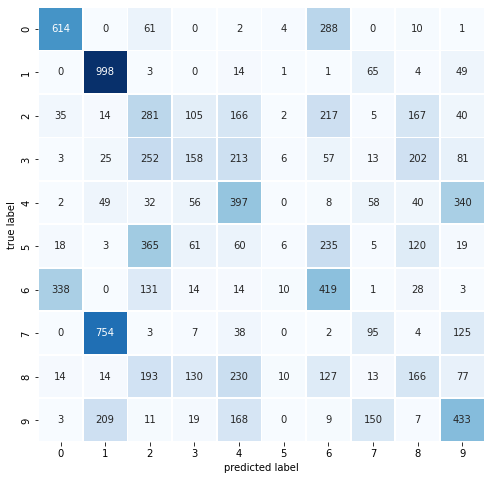

```python
plot_confusion_matrix(y_test,pred_classes)
```

The confusion matrix looks quite bad!

```python
def plot_digits(instances, pos, images_per_row=5, **options):
    size = 28
    images_per_row = min(len(instances), images_per_row)
    images = [instance.reshape(size,size) for instance in instances]
    n_rows = (len(instances) - 1) // images_per_row + 1
    row_images = []
    n_empty = n_rows * images_per_row - len(instances)
    images.append(np.zeros((size, size * n_empty)))
    for row in range(n_rows):
        rimages = images[row * images_per_row : (row + 1) * images_per_row]
        row_images.append(np.concatenate(rimages, axis=1))
    image = np.concatenate(row_images, axis=0)
    pos.imshow(image, cmap = 'binary', **options)
    pos.axis("off")
```

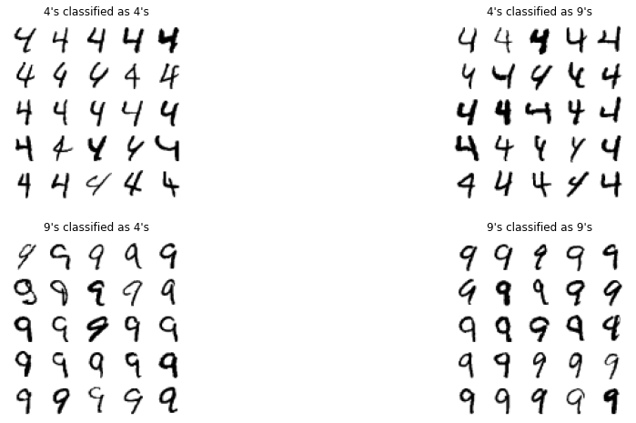

```python
cl_a, cl_b = 4, 9
X_aa = x_test_norm[(y_test == cl_a) & (pred_classes == cl_a)]
X_ab = x_test_norm[(y_test == cl_a) & (pred_classes == cl_b)]
X_ba = x_test_norm[(y_test == cl_b) & (pred_classes == cl_a)]
X_bb = x_test_norm[(y_test == cl_b) & (pred_classes == cl_b)]

plt.figure(figsize=(16,8))

p1 = plt.subplot(221)
p2 = plt.subplot(222)
p3 = plt.subplot(223)
p4 = plt.subplot(224)

plot_digits(X_aa[:25], p1, images_per_row=5);
plot_digits(X_ab[:25], p2, images_per_row=5);
plot_digits(X_ba[:25], p3, images_per_row=5);
plot_digits(X_bb[:25], p4, images_per_row=5);


p1.set_title(f"{cl_a}'s classified as {cl_a}'s")
p2.set_title(f"{cl_a}'s classified as {cl_b}'s")
p3.set_title(f"{cl_b}'s classified as {cl_a}'s")
p4.set_title(f"{cl_b}'s classified as {cl_b}'s")

# plt.savefig("error_analysis_digits_plot_EXP1_valid")

plt.show()
```

```python
def plot_confusion_matrix(matrix):
    """If you prefer color and a colorbar"""
    fig = plt.figure(figsize=(8,8))
    ax = fig.add_subplot(111)
    cax = ax.matshow(matrix)
    fig.colorbar(cax)
```

Visualizing Confusion Matrix

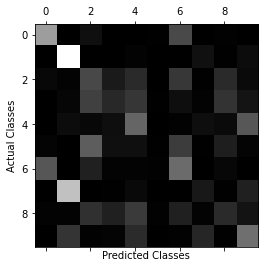

```python
plt.matshow(conf_mx, cmap=plt.cm.gray)
plt.xlabel("Predicted Classes")
plt.ylabel("Actual Classes")
#plt.savefig("confusion_matrix_plot_mnist", tight_layout=False)
plt.show()
```

## 8. Analyzing the Activation Values of the Hidden Nodes

We want to examine the contribution of the individual hidden nodes to the classifications made by the model. We first get the activation values of all the hidden nodes for each of the 60,000 training images and treat these *1 activation* as the features that determine the classification class. For the sake of comparison, we also consider the *784 pixels* of each training image and determine the contribution of the individual pixels to the predicted classification class.

We use the following two articles as reference

- https://towardsdatascience.com/pca-using-python-scikit-learn-e653f8989e60
- https://towardsdatascience.com/visualising-high-dimensional-datasets-using-pca-and-t-sne-in-python-8ef87e7915b

### Get the activation values of the hidden nodes

To get the activation values of the hidden nodes, we need to create a new model, `activation_model`, that takes the same input as our current model but outputs the activation value of the hidden layer, i.e. of the hidden node. Then use the `predict` function to get the activation values.

```python
# Extracts the outputs of the 2 layers:
layer_outputs = [layer.output for layer in model.layers]

# Creates a model that will return these outputs, given the model input:
activation_model = models.Model(inputs=model.input, outputs=layer_outputs)

print(f"There are {len(layer_outputs)} layers")
layer_outputs; # description of the layers
```

```
There are 2 layers
```

```python
# Get the outputs of all the hidden nodes for each of the 60000 training images
activations = activation_model.predict(x_train_norm)
hidden_layer_activation = activations[0]
output_layer_activations = activations[1]
hidden_layer_activation.shape   #  each of the 1 hidden node has one activation value per training image
```

```
(60000, 1)
```

```python
output_layer_activations.shape
```

```
(60000, 10)
```

```python
print(f"The maximum activation value of the hidden nodes in the hidden layer is \
{hidden_layer_activation.max()}")
```

```
The maximum activation value of the hidden nodes in the hidden layer is 11.725711822509766
```

```python
# Some stats about the output layer as an aside...
np.set_printoptions(suppress = True)  # display probabilities as decimals and NOT in scientific notation
ouput_layer_activation = activations[1]
print(f"The output node has shape {ouput_layer_activation.shape}")
print(f"The output for the first image are {ouput_layer_activation[0].round(4)}")
print(f"The sum of the probabilities is (approximately) {ouput_layer_activation[0].sum()}")
```

```
The output node has shape (60000, 10)
The output for the first image are [0.041 0.    0.209 0.17  0.067 0.19  0.128 0.    0.183 0.012]
The sum of the probabilities is (approximately) 0.9999999403953552
```

### Create a dataframe with the activation values and the class labels

```python
#Get the dataframe of all the node values
activation_data = {'actual_class':y_train}
for k in range(0,1):
    activation_data[f"act_val_{k}"] = hidden_layer_activation[:,k]

activation_df = pd.DataFrame(activation_data)
activation_df.head(15).round(3).T
```

|  | 0 | 1 | 2 | 3 | 4 | 5 | 6 | 7 | 8 | 9 | 10 | 11 | 12 | 13 | 14 |
| --- | --- | --- | --- | --- | --- | --- | --- | --- | --- | --- | --- | --- | --- | --- | --- |
| actual_class | 5.000 | 0.000 | 4.000 | 1.000 | 9.000 | 2.000 | 1.0 | 3.00 | 1.0 | 4.000 | 3.000 | 5.000 | 3.000 | 6.000 | 1.0 |
| act_val_0 | 3.055 | 5.075 | 0.329 | 0.001 | 0.772 | 2.211 | 0.0 | 2.85 | 0.0 | 1.541 | 1.486 | 2.371 | 2.253 | 4.052 | 0.0 |

### Visualize the activation values with boxplots

We get the activation values of the first hidden node and combine them with the corresponding class labels into a DataFrame. We use both `matplotlib` and `seaborn` to create boxplots from the dataframe.

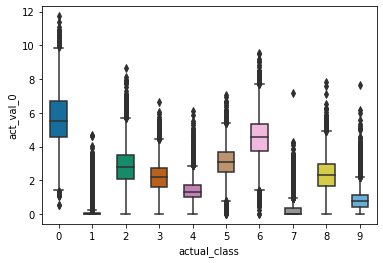

```python
# To see how closely the hidden node activation values correlate with the class labels
# Let us use seaborn for the boxplots this time.
bplot = sns.boxplot(y='act_val_0', x='actual_class',
                 data=activation_df[['act_val_0','actual_class']],
                 width=0.5,
                 palette="colorblind")
```

```python
# displaying the range of activation values for each class labels
activation_df.groupby("actual_class")["act_val_0"].apply(lambda x: [round(min(x.tolist()),2),
 round(max(x.tolist()),2)]).reset_index().rename(columns={"act_val_0": "range_of_act_values"})
```

[output not shown]

### Create a dataframe with the pixel values and class labels

```python
#Get the dataframe of all the pixel values
pixel_data = {'actual_class':y_train}
for k in range(0,784):
    pixel_data[f"pix_val_{k}"] = x_train_norm[:,k]
pixel_df = pd.DataFrame(pixel_data)
pixel_df.head(15).round(3).T
```

|  | 0 | 1 | 2 | 3 | 4 | 5 | 6 | 7 | 8 | 9 | 10 | 11 | 12 | 13 | 14 |
| --- | --- | --- | --- | --- | --- | --- | --- | --- | --- | --- | --- | --- | --- | --- | --- |
| actual_class | 5.0 | 0.0 | 4.0 | 1.0 | 9.0 | 2.0 | 1.0 | 3.0 | 1.0 | 4.0 | 3.0 | 5.0 | 3.0 | 6.0 | 1.0 |
| pix_val_0 | 0.0 | 0.0 | 0.0 | 0.0 | 0.0 | 0.0 | 0.0 | 0.0 | 0.0 | 0.0 | 0.0 | 0.0 | 0.0 | 0.0 | 0.0 |
| pix_val_1 | 0.0 | 0.0 | 0.0 | 0.0 | 0.0 | 0.0 | 0.0 | 0.0 | 0.0 | 0.0 | 0.0 | 0.0 | 0.0 | 0.0 | 0.0 |
| pix_val_2 | 0.0 | 0.0 | 0.0 | 0.0 | 0.0 | 0.0 | 0.0 | 0.0 | 0.0 | 0.0 | 0.0 | 0.0 | 0.0 | 0.0 | 0.0 |
| pix_val_3 | 0.0 | 0.0 | 0.0 | 0.0 | 0.0 | 0.0 | 0.0 | 0.0 | 0.0 | 0.0 | 0.0 | 0.0 | 0.0 | 0.0 | 0.0 |
| ... | ... | ... | ... | ... | ... | ... | ... | ... | ... | ... | ... | ... | ... | ... | ... |
| pix_val_779 | 0.0 | 0.0 | 0.0 | 0.0 | 0.0 | 0.0 | 0.0 | 0.0 | 0.0 | 0.0 | 0.0 | 0.0 | 0.0 | 0.0 | 0.0 |
| pix_val_780 | 0.0 | 0.0 | 0.0 | 0.0 | 0.0 | 0.0 | 0.0 | 0.0 | 0.0 | 0.0 | 0.0 | 0.0 | 0.0 | 0.0 | 0.0 |
| pix_val_781 | 0.0 | 0.0 | 0.0 | 0.0 | 0.0 | 0.0 | 0.0 | 0.0 | 0.0 | 0.0 | 0.0 | 0.0 | 0.0 | 0.0 | 0.0 |
| pix_val_782 | 0.0 | 0.0 | 0.0 | 0.0 | 0.0 | 0.0 | 0.0 | 0.0 | 0.0 | 0.0 | 0.0 | 0.0 | 0.0 | 0.0 | 0.0 |
| pix_val_783 | 0.0 | 0.0 | 0.0 | 0.0 | 0.0 | 0.0 | 0.0 | 0.0 | 0.0 | 0.0 | 0.0 | 0.0 | 0.0 | 0.0 | 0.0 |

785 rows × 15 columns

```python
pixel_df.pix_val_77.value_counts()
```

```
0.000000    59720
1.000000       25
0.996078       13
0.992157        9
0.050980        6
            ...
0.392157        1
0.717647        1
0.215686        1
0.925490        1
0.937255        1
Name: pix_val_77, Length: 150, dtype: int64
```

```python
pixel_df.pix_val_78.value_counts()
```

```
0.000000    59862
1.000000        6
0.141176        4
0.960784        4
0.992157        4
            ...
0.749020        1
0.717647        1
0.345098        1
0.968627        1
0.654902        1
Name: pix_val_78, Length: 97, dtype: int64
```

### Use a scatter plot to visualize the predicive power of the pixel values at two fixed locations in the image, i.e. how well the pixel values at two fixed locations in the image "predict" the class labels.

We use a scatter plot to determine the correlation between the `pix_val_77` and `pix_val_78` values and the `actual_class` values.

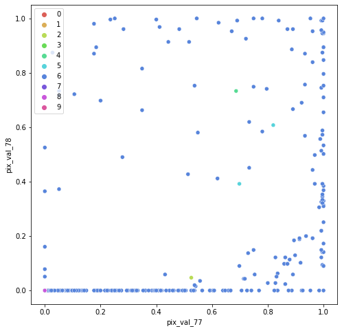

```python
plt.figure(figsize=(8, 8))
color = sns.color_palette("hls", 10)
sns.scatterplot(x="pix_val_77", y="pix_val_78", hue="actual_class",  palette=color, data = pixel_df, legend="full")
plt.legend(loc='upper left');
```

## 10. Reducing dimensionality of the data with Random Forests.

**sklearn.ensemble.RandomForestClassifier**  
https://scikit-learn.org/stable/modules/generated/sklearn.ensemble.RandomForestClassifier.html

```python
rnd_clf = RandomForestClassifier(n_estimators=100, random_state=42)
rnd_clf.fit(x_train_norm,y_train_encoded)
```

```
RandomForestClassifier(bootstrap=True, ccp_alpha=0.0, class_weight=None,
                       criterion='gini', max_depth=None, max_features='auto',
                       max_leaf_nodes=None, max_samples=None,
                       min_impurity_decrease=0.0, min_impurity_split=None,
                       min_samples_leaf=1, min_samples_split=2,
                       min_weight_fraction_leaf=0.0, n_estimators=100,
                       n_jobs=None, oob_score=False, random_state=42, verbose=0,
                       warm_start=False)
```

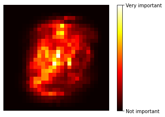

```python
def plot_digit(data):
    image = data.reshape(28, 28)
    plt.imshow(image, cmap = 'hot',
               interpolation="nearest")
    plt.axis("off")

plot_digit(rnd_clf.feature_importances_)
cbar = plt.colorbar(ticks=[rnd_clf.feature_importances_.min(), rnd_clf.feature_importances_.max()])
cbar.ax.set_yticklabels(['Not important', 'Very important'])
plt.show()
```

```python
# https://stackoverflow.com/questions/6910641/how-do-i-get-indices-of-n-maximum-values-in-a-numpy-array
n = 70
imp_arr = rnd_clf.feature_importances_
idx = (-imp_arr).argsort()[:n]          # get the indices of the 70 "most important" features/pixels
len(idx)
```

```
70
```

```python
# Create training and test images using just the 70 pixel locations obtained above
train_images_sm = x_train_norm[:,idx]
test_images_sm = x_test_norm[:,idx]
train_images_sm.shape, test_images_sm.shape # the reduced images have dimension 70
```

```
((60000, 70), (10000, 70))
```

### Visualize the 70 pixels

We convert the array of indexes to ordered pairs and plot them as red circles on the second training image. These are the features (pixels) we train our neural network on.

```python
# to convert an index n, 0<= n < 784
def pair(n,size):
    x = n//size
    y = n%size
    return x,y
```

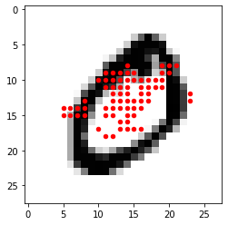

```python
plt.imshow(x_train_norm[1].reshape(28,28),cmap='binary')
x, y = np.array([pair(k,28) for k in idx]).T
plt.scatter(x,y,color='red',s=20)
```